# PCA_MNIST

## Mini-Projeto 2023 - 3.1 "Aplicação do PCA em reconhecimento de dígitos"

### Grupo 4

- Gabriella Lima, pg54401
- Guilherme Martins, pg52214
- Maria Laires, pg52220
- Matheus Ribeiro, pg52254

### Métricas em Machine Learning - Metrado em Matemática e Computação

#### Ano letivo 2023-24 ; 1º semestre - 1º ano

A base de dados MNIST foi acedida a partir do website "WayBack Machine" (registo Março de 2022) através do link: https://web.archive.org/web/20220331130319/https://yann.lecun.com/exdb/mnist/ , no dia 20 de dezembro de 2023

- Leitura das imagens de treino

[output not shown]

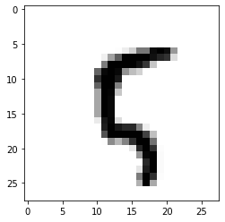

```python
import numpy as np
import idx2numpy
import matplotlib.pyplot as plt

imagefile = 'mnist_database/train-images.idx3-ubyte'
imagearray = idx2numpy.convert_from_file(imagefile)
size = len(imagearray) # nº de imagens para processar

print(imagearray.shape)
print(imagearray[100])

X = [] # novo repositório das imagens

for i in range(0,size):
    aux = imagearray[i].flatten() # transformar cada imagem (matriz) num array simples (linear)
    X.append(aux)

print(len(X))

# apenas um exemplo
plt.imshow(np.reshape(X[100], (28,28)), cmap=plt.cm.binary)

labelfile = 'mnist_database/train-labels.idx1-ubyte'
labelarray = idx2numpy.convert_from_file(labelfile)

print(labelarray[100])
```

```
Distribuição das Labels: 0: 5923 ; 1: 6742 ; 2: 5958 ; 3: 6131 ; 4: 5842
 ; 5: 5421 ; 6: 5918 ; 7: 6265 ; 8: 5851 ; 9: 5949
```

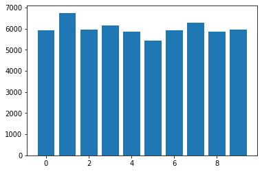

```python
# Organizar as imagens por dígito

X_digito = [[],[],[],[],[],[],[],[],[],[]]

for i in range(0,len(X)):
    n = labelarray[i]
    X_digito[n].append(X[i])


print("Distribuição das Labels: 0: "+str(len(X_digito[0]))+" ; 1: "+str(len(X_digito[1]))+" ; 2: "+str(len(X_digito[2]))+" ; 3: "+str(len(X_digito[3]))+" ; 4: "+str(len(X_digito[4])))
print(" ; 5: "+str(len(X_digito[5]))+" ; 6: "+str(len(X_digito[6]))+" ; 7: "+str(len(X_digito[7]))+" ; 8: "+str(len(X_digito[8]))+" ; 9: "+str(len(X_digito[9])))

# Gráfico que mostra que cada número aparece aproximadamente igual a 6000 vezes
counts = [len(X_digito[0]), len(X_digito[1]), len(X_digito[2]), len(X_digito[3]), len(X_digito[4]), len(X_digito[5]), len(X_digito[6]), len(X_digito[7]), len(X_digito[8]), len(X_digito[9])]
labels = [0,1,2,3,4,5,6,7,8,9]
plt.bar(labels, counts)
plt.show()
```

- Exemplos de imagens para cada um dos dígitos

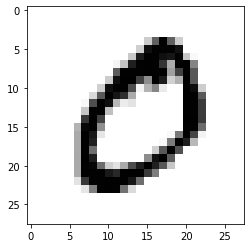

```python
# exemplo de imagem dígito 0
plt.imshow(np.reshape(X_digito[0][0], (28,28)), cmap=plt.cm.binary)
```

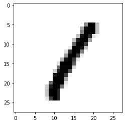

```python
# exemplo de imagem dígito 1
plt.imshow(np.reshape(X_digito[1][0], (28,28)), cmap=plt.cm.binary)
```

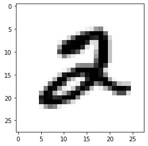

```python
# exemplo de imagem dígito 2
plt.imshow(np.reshape(X_digito[2][0], (28,28)), cmap=plt.cm.binary)
```

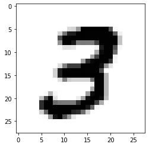

```python
# exemplo de imagem dígito 3
plt.imshow(np.reshape(X_digito[3][0], (28,28)), cmap=plt.cm.binary)
```

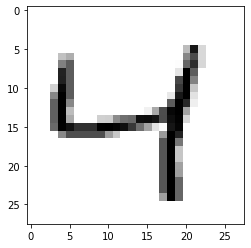

```python
# exemplo de imagem dígito 4
plt.imshow(np.reshape(X_digito[4][0], (28,28)), cmap=plt.cm.binary)
```

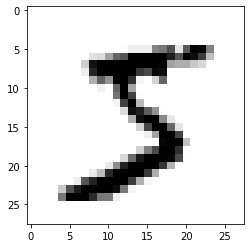

```python
# exemplo de imagem dígito 5
plt.imshow(np.reshape(X_digito[5][0], (28,28)), cmap=plt.cm.binary)
```

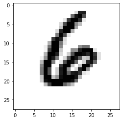

```python
# exemplo de imagem dígito 6
plt.imshow(np.reshape(X_digito[6][0], (28,28)), cmap=plt.cm.binary)
```

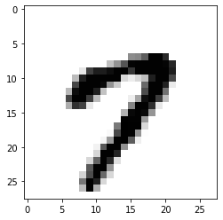

```python
# exemplo de imagem dígito 7
plt.imshow(np.reshape(X_digito[7][0], (28,28)), cmap=plt.cm.binary)
```

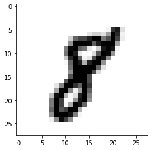

```python
# exemplo de imagem dígito 8
plt.imshow(np.reshape(X_digito[8][0], (28,28)), cmap=plt.cm.binary)
```

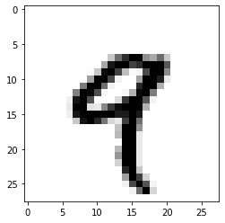

```python
# exemplo de imagem dígito 9
plt.imshow(np.reshape(X_digito[9][0], (28,28)), cmap=plt.cm.binary)
```

```python
# Implementação do PCA
# Obter os vetores próprios das componentes principais de acordo com um certo nivel de confianca
def pca(X, confianca_alvo):
    # Media de todas as imagens
    media = np.mean(X, 0)

    # Centralizar os dados
    phi = X - media

    # Calcular os vetores e valores proprios atraves do SVD
    vet_prop, sigma, v = np.linalg.svd(phi.transpose(), full_matrices=False) # v = variância
    val_prop = sigma*sigma

    # Ordenar valores próprios por ordem Decrescente
    idx = np.argsort(-val_prop)
    val_prop = val_prop[idx]
    vet_prop = vet_prop[:,idx]

    # Determinar o nº de vetores próprios a usar de acordo com a confiança-alvo
    k = 0
    traco = np.sum(val_prop)
    confianca = 0
    while(confianca < confianca_alvo):
        confianca = np.sum(val_prop[:k])/traco
        k = k+1

    # Escolher os vetores próprios associados às componentes principais
    vet_prop = vet_prop[:,0:k]
    return k, val_prop, vet_prop, phi, media, v, confianca
```

```
63
```

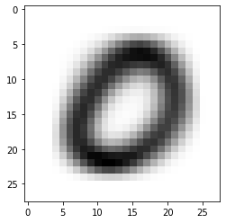

```python
# Exemplo para o dígito 0
k_0, val_prop_0, vet_prop_0, phi_0, media_0, v_0, confianca_0 = pca(X_digito[0], 0.9)

plt.imshow(np.reshape(media_0, (28,28)), cmap=plt.cm.binary) # visualização da imagem média do dígito

#len(vet_prop_0)
len(vet_prop_0[0])
#len(val_prop_0[0])
#val_prop_0[0]
```

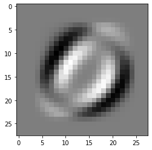

```python
# Exemplo resultante de um vetores próprios / uma das componentes principais da imagem
plt.imshow(np.reshape(vet_prop_0.T[0], (28,28)), cmap=plt.cm.binary) # visualização da imagem média do dígito
```

```python
coef_proj = [[],[],[],[],[],[],[],[],[],[]]

# Calculo dos coeficientes da projecao
def coefProj(phi, vet_prop, size):
    coef_proj = [np.dot(phi[i], vet_prop) for i in range(size)]
    return coef_proj

# Obter os coeficientes das projecoes (para o dígito 0)
coef_proj[0] = coefProj(phi_0, vet_prop_0, len(X_digito[0]))
#coef_proj[0]
```

#### Elbow Method (Método do Cotovelo)

Método Heurístico para verificar se o valor da confiança-alvo foi adequada para a conservação da informação

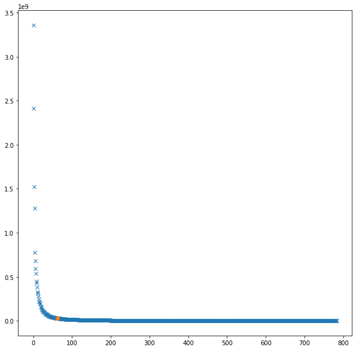

```python
# Gráfico do Método do cotovelo
plt.figure(figsize=(10,10))
t = np.arange(0, len(val_prop_0), 1)
plt.plot(t, val_prop_0, 'x')
plt.plot(k_0, val_prop_0[k_0], 'o')
plt.show()
```

## Aplicação do PCA nos restantes dígitos [1..9]

```python
k_1, val_prop_1, vet_prop_1, phi_1, media_1, v_1, confianca_1 = pca(X_digito[1], 0.9)
k_2, val_prop_2, vet_prop_2, phi_2, media_2, v_2, confianca_2 = pca(X_digito[2], 0.9)
k_3, val_prop_3, vet_prop_3, phi_3, media_3, v_3, confianca_3 = pca(X_digito[3], 0.9)
k_4, val_prop_4, vet_prop_4, phi_4, media_4, v_4, confianca_4 = pca(X_digito[4], 0.9)
k_5, val_prop_5, vet_prop_5, phi_5, media_5, v_5, confianca_5 = pca(X_digito[5], 0.9)
k_6, val_prop_6, vet_prop_6, phi_6, media_6, v_6, confianca_6 = pca(X_digito[6], 0.9)
k_7, val_prop_7, vet_prop_7, phi_7, media_7, v_7, confianca_7 = pca(X_digito[7], 0.9)
k_8, val_prop_8, vet_prop_8, phi_8, media_8, v_8, confianca_8 = pca(X_digito[8], 0.9)
k_9, val_prop_9, vet_prop_9, phi_9, media_9, v_9, confianca_9 = pca(X_digito[9], 0.9)

# Juntar todos os resultados
k_digito = [k_0, k_1, k_2, k_3, k_4, k_5, k_6, k_7, k_8, k_9]
val_prop_digito = [val_prop_0, val_prop_1, val_prop_2, val_prop_3, val_prop_4, val_prop_5, val_prop_6, val_prop_7, val_prop_8, val_prop_9]
vet_prop_digito = [vet_prop_0, vet_prop_1, vet_prop_2, vet_prop_3, vet_prop_4, vet_prop_5, vet_prop_6, vet_prop_7, vet_prop_8, vet_prop_9]
phi_digito = [phi_0, phi_1, phi_2, phi_3, phi_4, phi_5, phi_6, phi_7, phi_8, phi_9]
media_digito = [media_0, media_1, media_2, media_3, media_4, media_5, media_6, media_7, media_8, media_9]
v_digito = [v_0, v_1, v_2, v_3, v_4, v_5, v_6, v_7, v_8, v_9]
confianca_digito = [confianca_0, confianca_1, confianca_2, confianca_3, confianca_4, confianca_5, confianca_6, confianca_7, confianca_8, confianca_9]
```

Número de valores próprios para cada modelo de dígito

```python
k_digito
```

```
[63, 37, 82, 81, 77, 76, 63, 67, 83, 63]
```

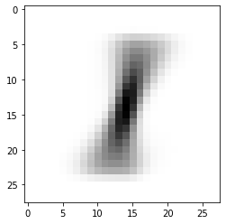

```python
plt.imshow(np.reshape(media_1, (28,28)), cmap=plt.cm.binary) # visualização da imagem média do dígito
```

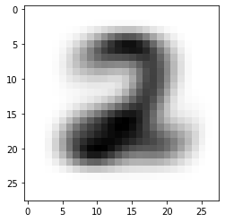

```python
plt.imshow(np.reshape(media_2, (28,28)), cmap=plt.cm.binary) # visualização da imagem média do dígito
```

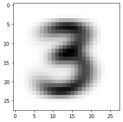

```python
plt.imshow(np.reshape(media_3, (28,28)), cmap=plt.cm.binary) # visualização da imagem média do dígito
```

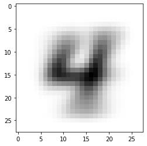

```python
plt.imshow(np.reshape(media_4, (28,28)), cmap=plt.cm.binary) # visualização da imagem média do dígito
```

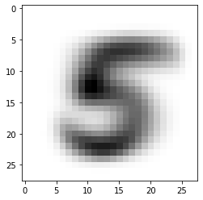

```python
plt.imshow(np.reshape(media_5, (28,28)), cmap=plt.cm.binary) # visualização da imagem média do dígito
```

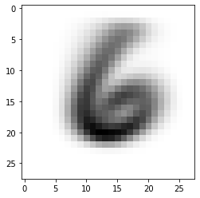

```python
plt.imshow(np.reshape(media_6, (28,28)), cmap=plt.cm.binary) # visualização da imagem média do dígito
```

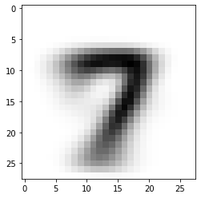

```python
plt.imshow(np.reshape(media_7, (28,28)), cmap=plt.cm.binary) # visualização da imagem média do dígito
```

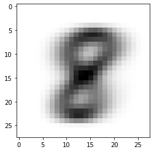

```python
plt.imshow(np.reshape(media_8, (28,28)), cmap=plt.cm.binary) # visualização da imagem média do dígito
```

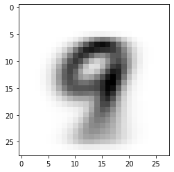

```python
plt.imshow(np.reshape(media_9, (28,28)), cmap=plt.cm.binary) # visualização da imagem média do dígito
```

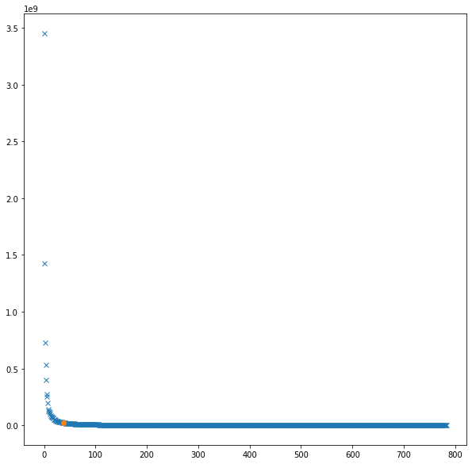

```python
plt.figure(figsize=(10,10))
t = np.arange(0, len(val_prop_1), 1)
plt.plot(t, val_prop_1, 'x')
plt.plot(k_1, val_prop_1[k_1], 'o')
plt.show()
```

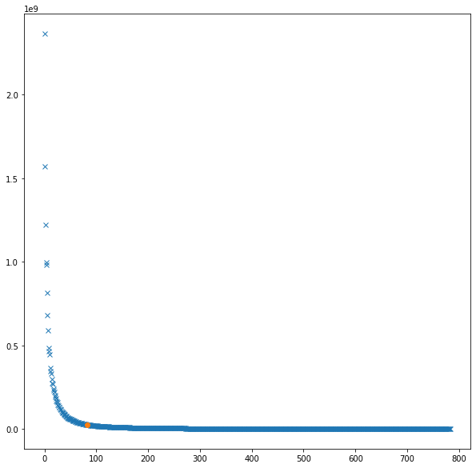

```python
plt.figure(figsize=(10,10))
t = np.arange(0, len(val_prop_2), 1)
plt.plot(t, val_prop_2, 'x')
plt.plot(k_2, val_prop_2[k_2], 'o')
plt.show()
```

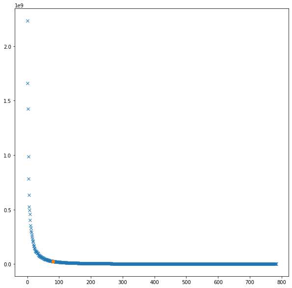

```python
plt.figure(figsize=(10,10))
t = np.arange(0, len(val_prop_3), 1)
plt.plot(t, val_prop_3, 'x')
plt.plot(k_3, val_prop_3[k_3], 'o')
plt.show()
```